# Red Wine Exploratory Data Analysis by Sanyam Chaudhary

```
##  [1] "X"                    "fixed.acidity"        "volatile.acidity"
##  [4] "citric.acid"          "residual.sugar"       "chlorides"
##  [7] "free.sulfur.dioxide"  "total.sulfur.dioxide" "density"
## [10] "pH"                   "sulphates"            "alcohol"
## [13] "quality"
```

```
##        X          fixed.acidity   volatile.acidity  citric.acid
##  Min.   :   1.0   Min.   : 4.60   Min.   :0.1200   Min.   :0.000
##  1st Qu.: 400.5   1st Qu.: 7.10   1st Qu.:0.3900   1st Qu.:0.090
##  Median : 800.0   Median : 7.90   Median :0.5200   Median :0.260
##  Mean   : 800.0   Mean   : 8.32   Mean   :0.5278   Mean   :0.271
##  3rd Qu.:1199.5   3rd Qu.: 9.20   3rd Qu.:0.6400   3rd Qu.:0.420
##  Max.   :1599.0   Max.   :15.90   Max.   :1.5800   Max.   :1.000
##  residual.sugar     chlorides       free.sulfur.dioxide
##  Min.   : 0.900   Min.   :0.01200   Min.   : 1.00
##  1st Qu.: 1.900   1st Qu.:0.07000   1st Qu.: 7.00
##  Median : 2.200   Median :0.07900   Median :14.00
##  Mean   : 2.539   Mean   :0.08747   Mean   :15.87
##  3rd Qu.: 2.600   3rd Qu.:0.09000   3rd Qu.:21.00
##  Max.   :15.500   Max.   :0.61100   Max.   :72.00
##  total.sulfur.dioxide    density             pH          sulphates
##  Min.   :  6.00       Min.   :0.9901   Min.   :2.740   Min.   :0.3300
##  1st Qu.: 22.00       1st Qu.:0.9956   1st Qu.:3.210   1st Qu.:0.5500
##  Median : 38.00       Median :0.9968   Median :3.310   Median :0.6200
##  Mean   : 46.47       Mean   :0.9967   Mean   :3.311   Mean   :0.6581
##  3rd Qu.: 62.00       3rd Qu.:0.9978   3rd Qu.:3.400   3rd Qu.:0.7300
##  Max.   :289.00       Max.   :1.0037   Max.   :4.010   Max.   :2.0000
##     alcohol         quality
##  Min.   : 8.40   Min.   :3.000
##  1st Qu.: 9.50   1st Qu.:5.000
##  Median :10.20   Median :6.000
##  Mean   :10.42   Mean   :5.636
##  3rd Qu.:11.10   3rd Qu.:6.000
##  Max.   :14.90   Max.   :8.000
```

# Univariate Plots Section

Distribution of a feature is demonstrated by histogram, boxplot and the summary stat function.

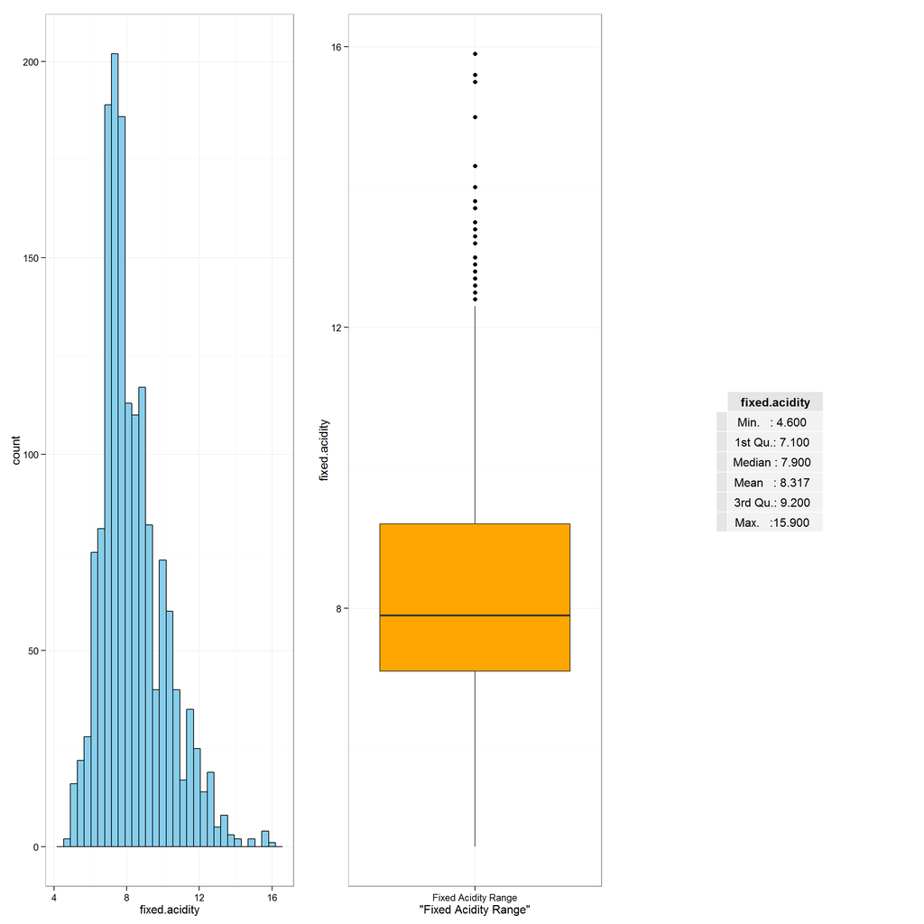

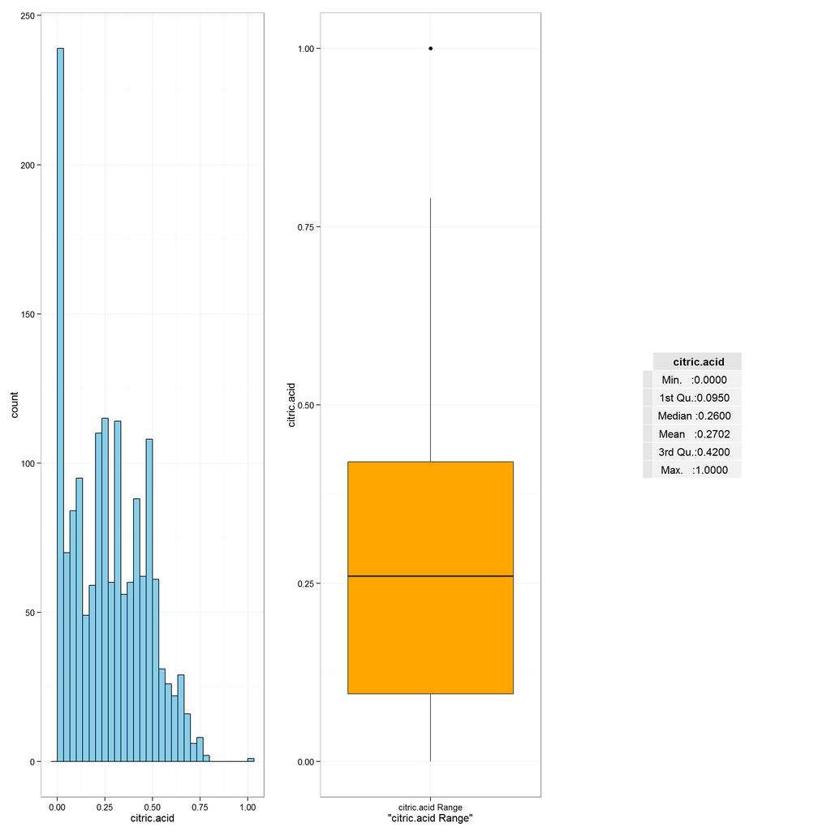

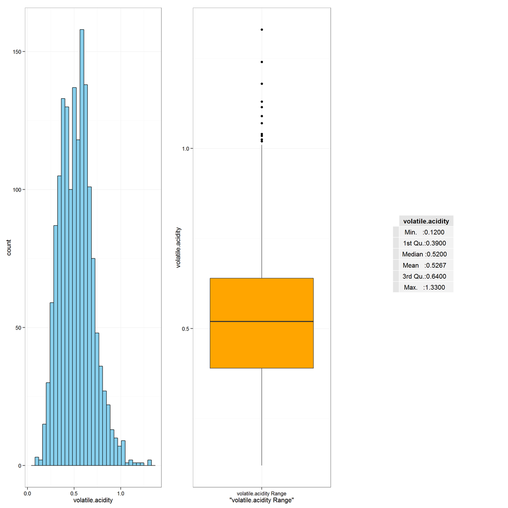

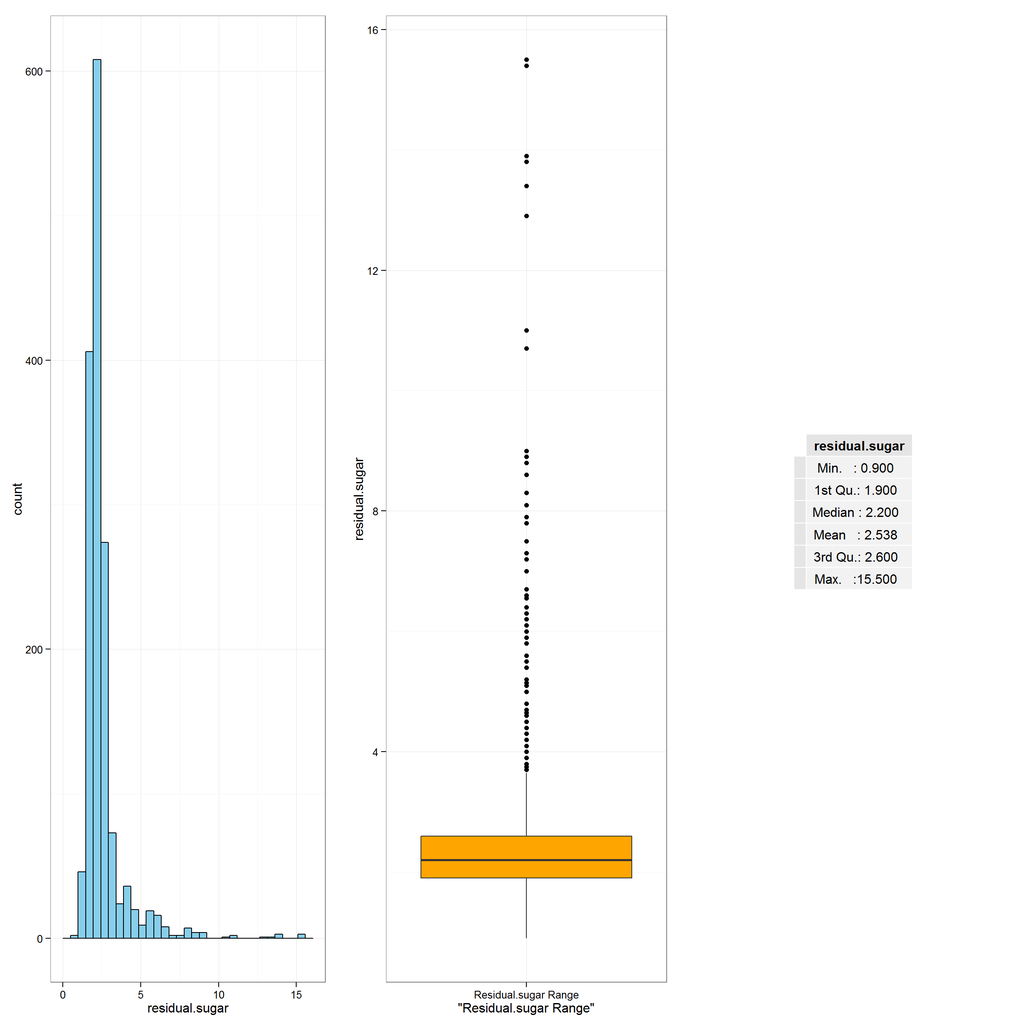

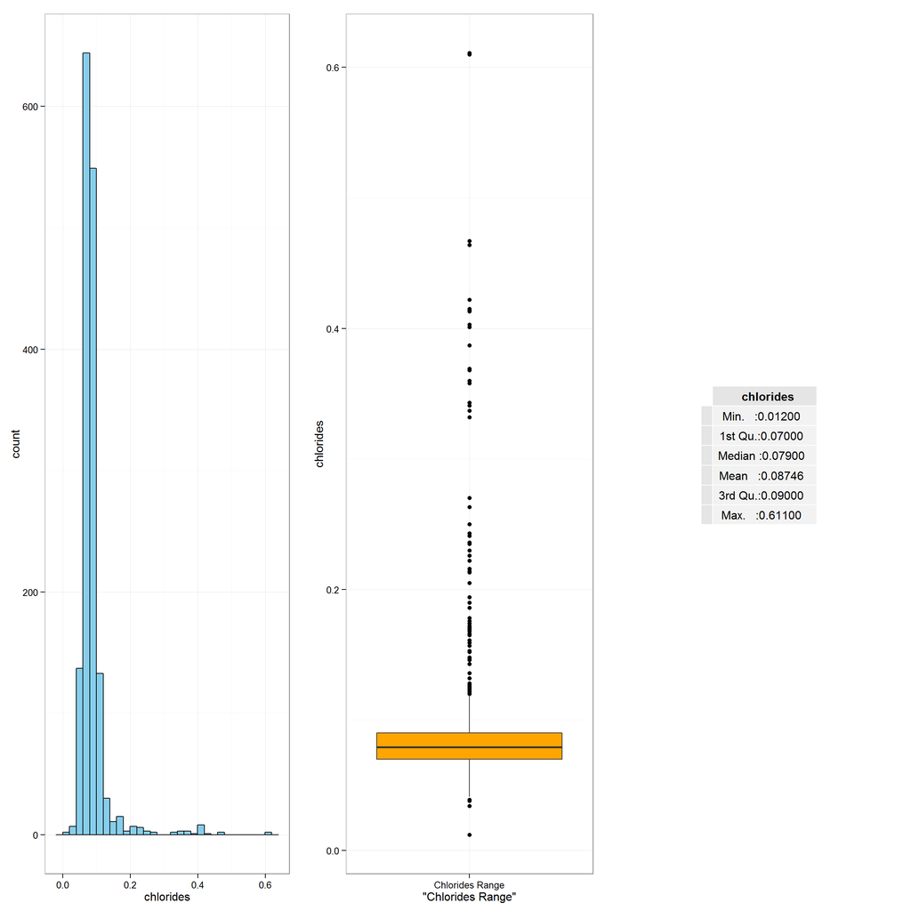

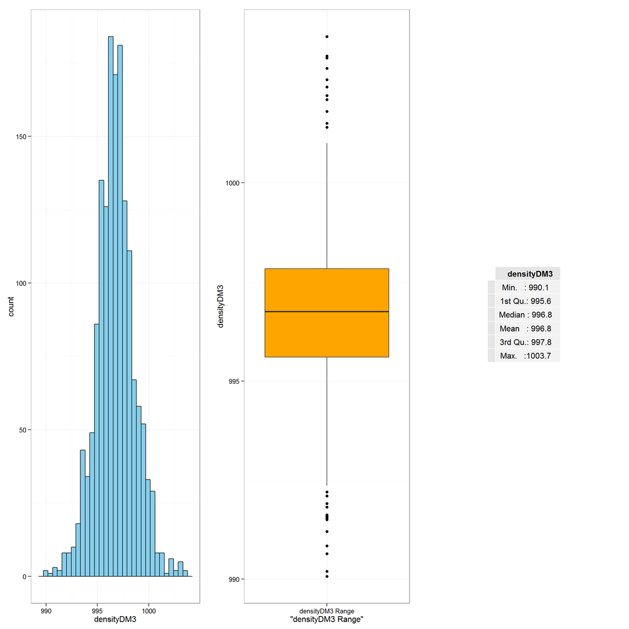

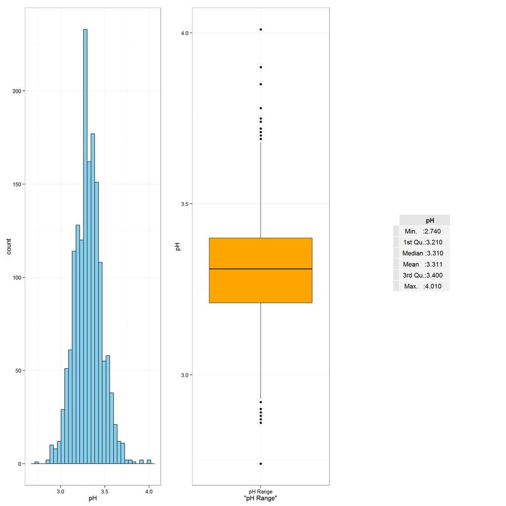

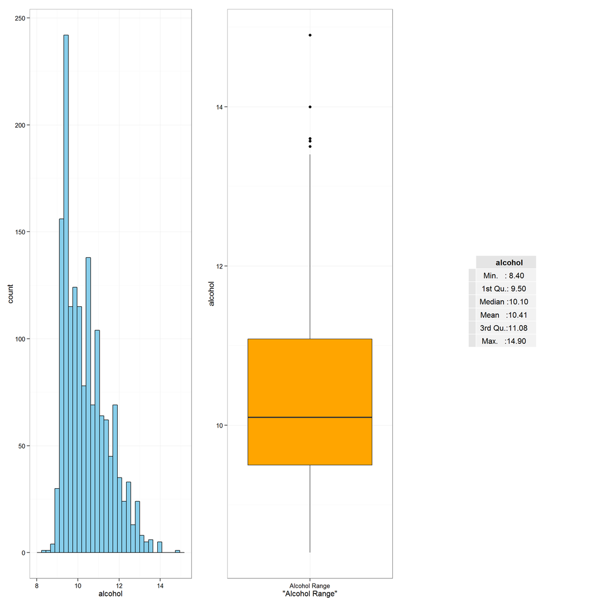

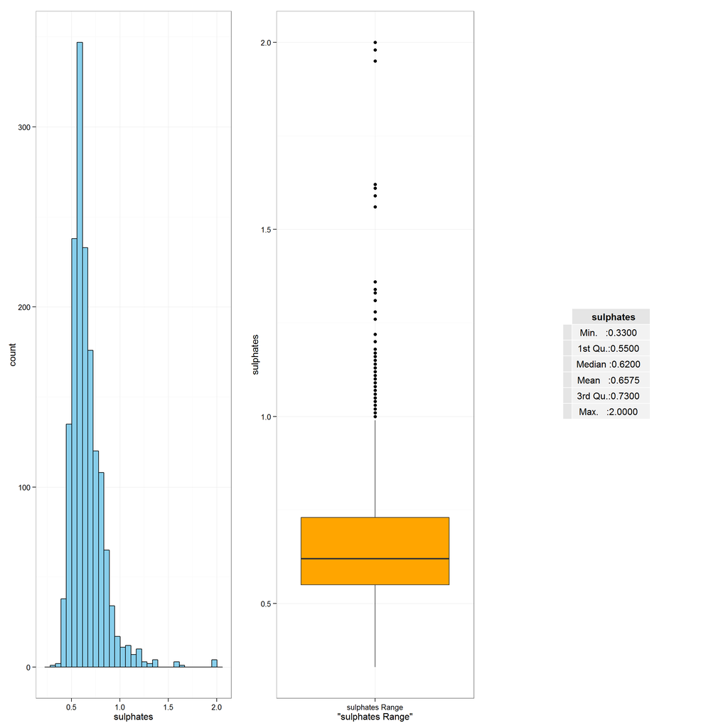

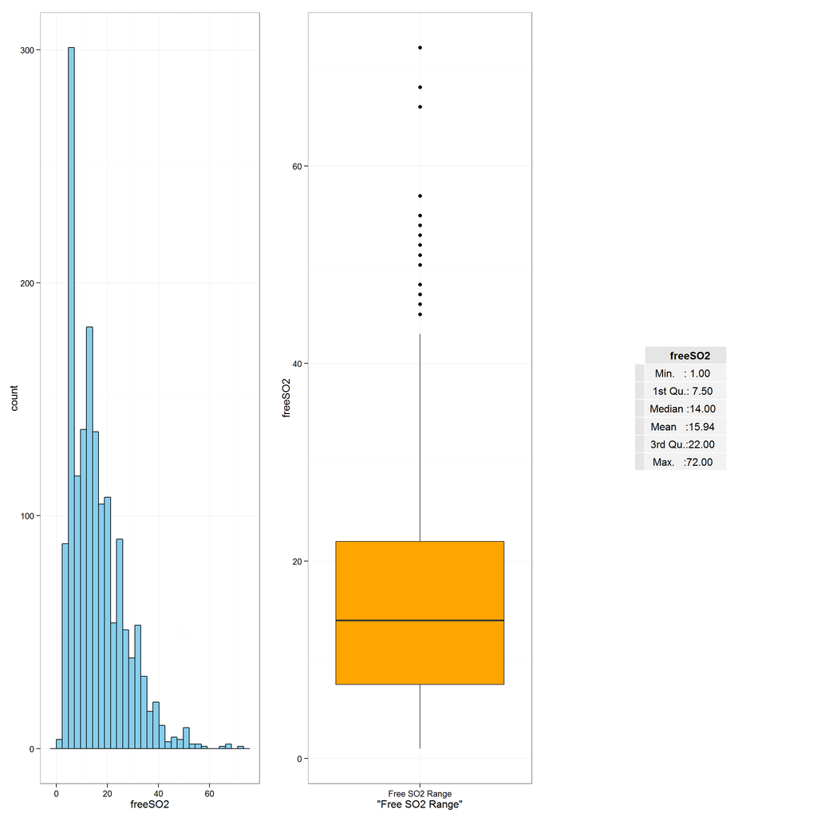

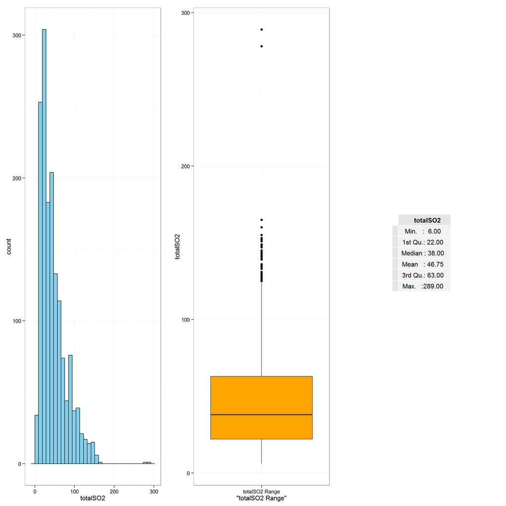

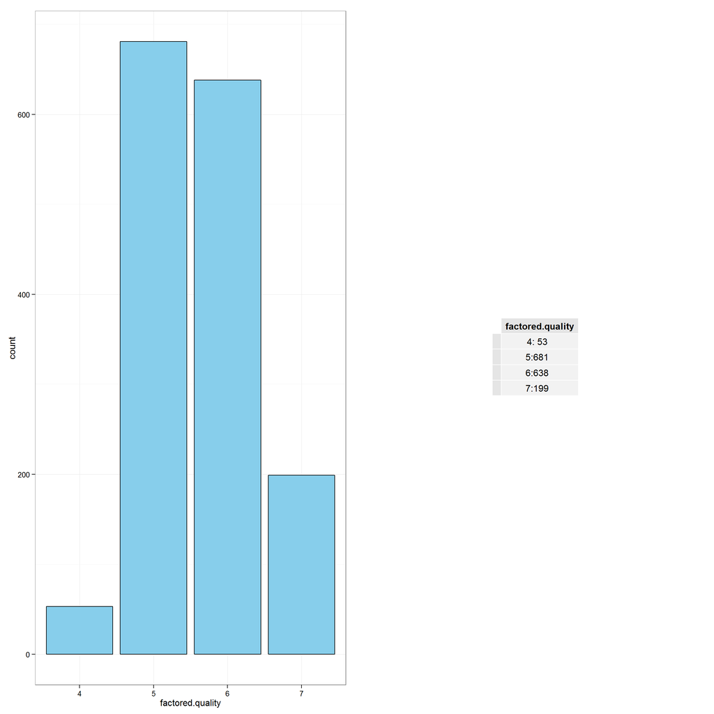

# Univariate Analysis

### What is the structure of your dataset?

Data set has 1599 observations with 13 variables. Out of those 13, 1 is index, 11 are physiocochemical variables and 1 quality is treated as main variable for this analysis.

### What is/are the main feature(s) of interest in your dataset?

Main feature for this dataset is quality. Effectively, I want to see from this data set that is there a relationship between quality and other variables and can we build a model to predict the quality of wine? Based on the lecture notes from class any correlation between 2 variables >.6 is strong and >.3 is meaningful, So I am going to keep an eye out for variables with that correlation.

### What other features in the dataset do you think will help support your investigation into your feature(s) of interest?

Based on the description of variables names, I am tempted to see the relation between alcohol, citric acid and other variables which are mentioned to downgrade or upgrade the quality of wine.

### Did you create any new variables from existing variables in the dataset?

Yes, I created a factored quality Variable.

### Of the features you investigated, were there any unusual distributions? Did you perform any operations on the data to tidy, adjust, or change the form of the data? If so, why did you do this?

Yes, I saw that distribution of quality variable is uneven, so much so that quality with level 3 and 8 have significantly low numbers. Since it is way smaller than mean of quality distribution per level, I have decided to remove level 3 and 8. I also calculated DensityDM i.e. multiply the existing Density *1000 to convert it into gm/dm^3 . I plan to plot it with residual sugar , which is expressed in gm/dm^3.

# Bivariate Plots Section

I want to start of with correlation matrix to see whats the correlation among different variables and plot the ones which had any meaningful relationships. I am going to use corrplot package for this.

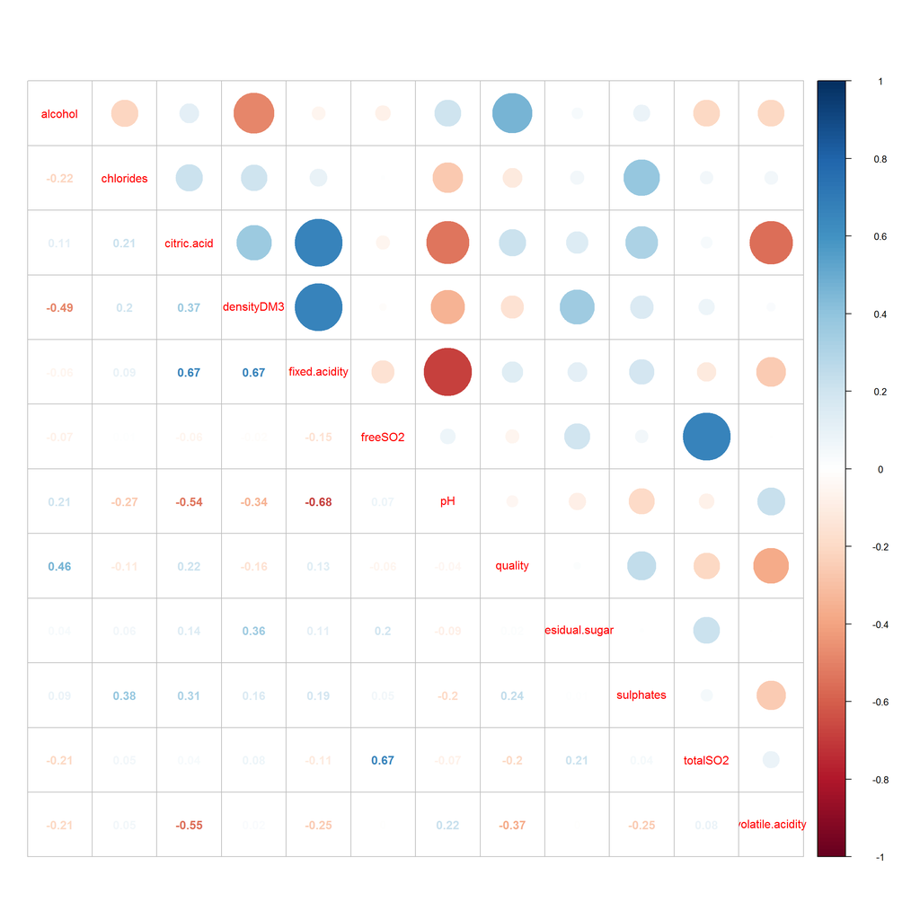

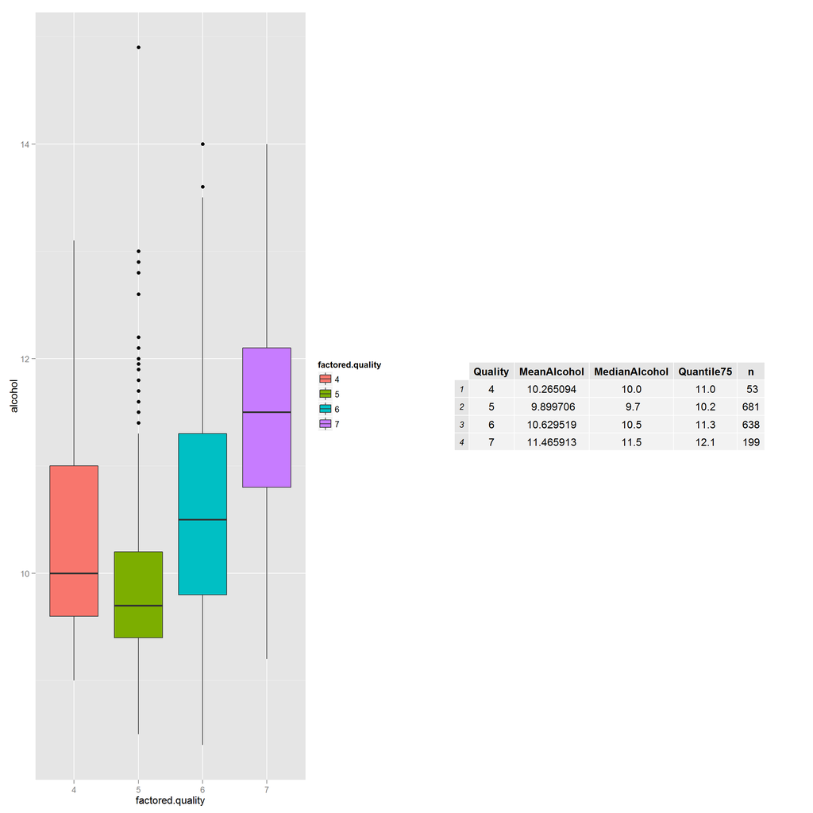

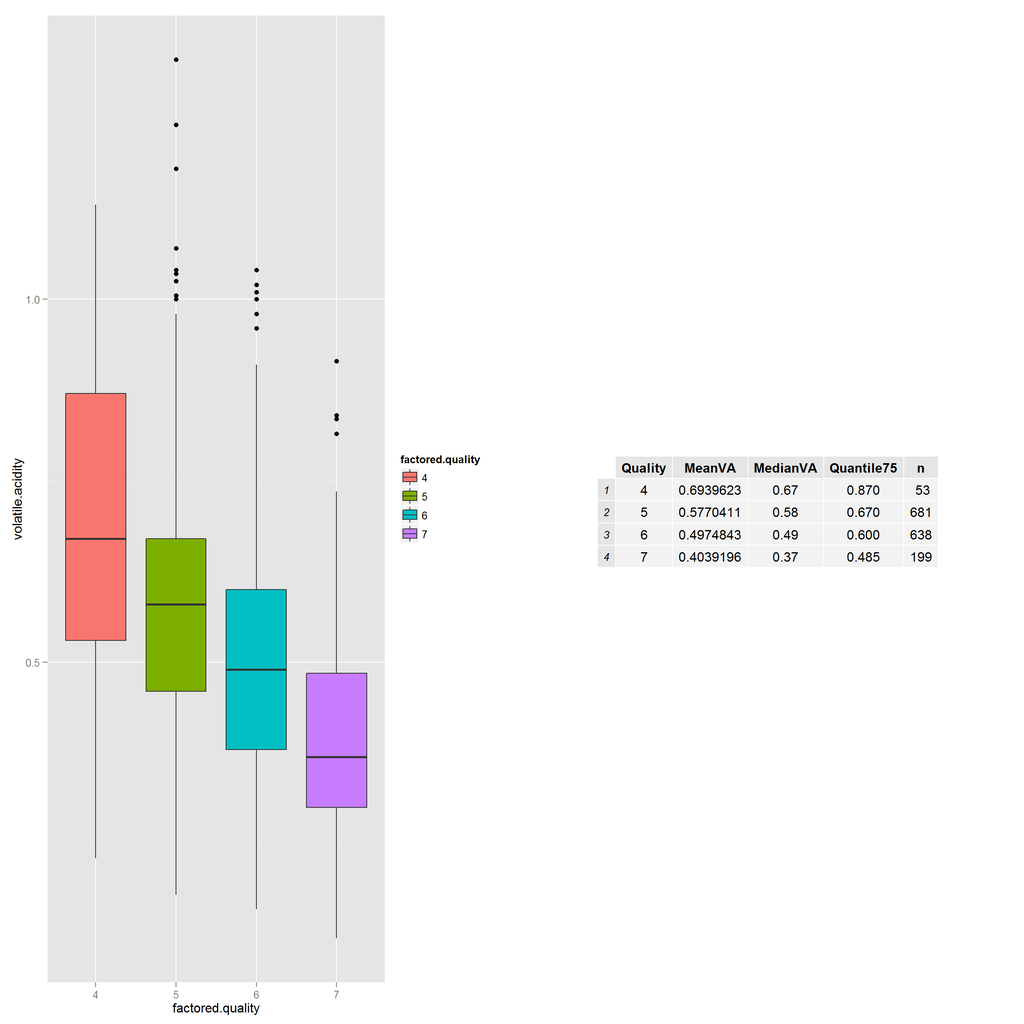

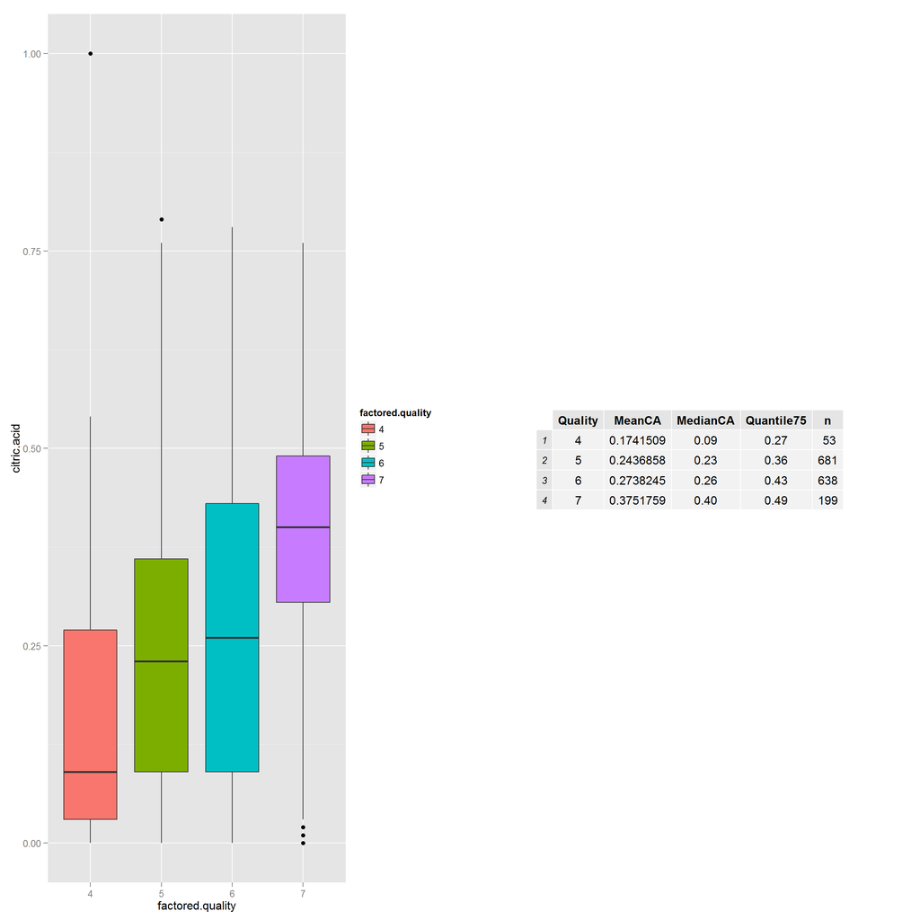

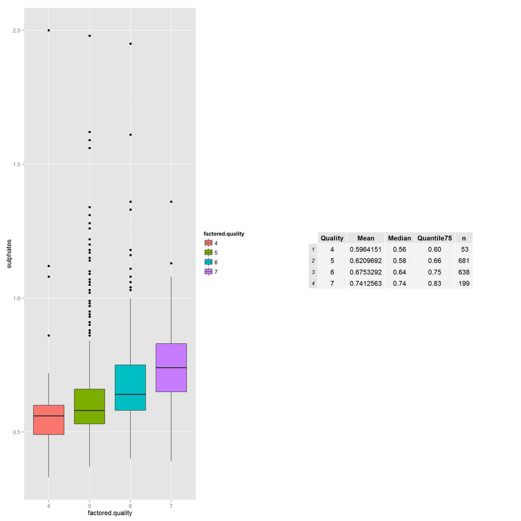

[figure not shown]

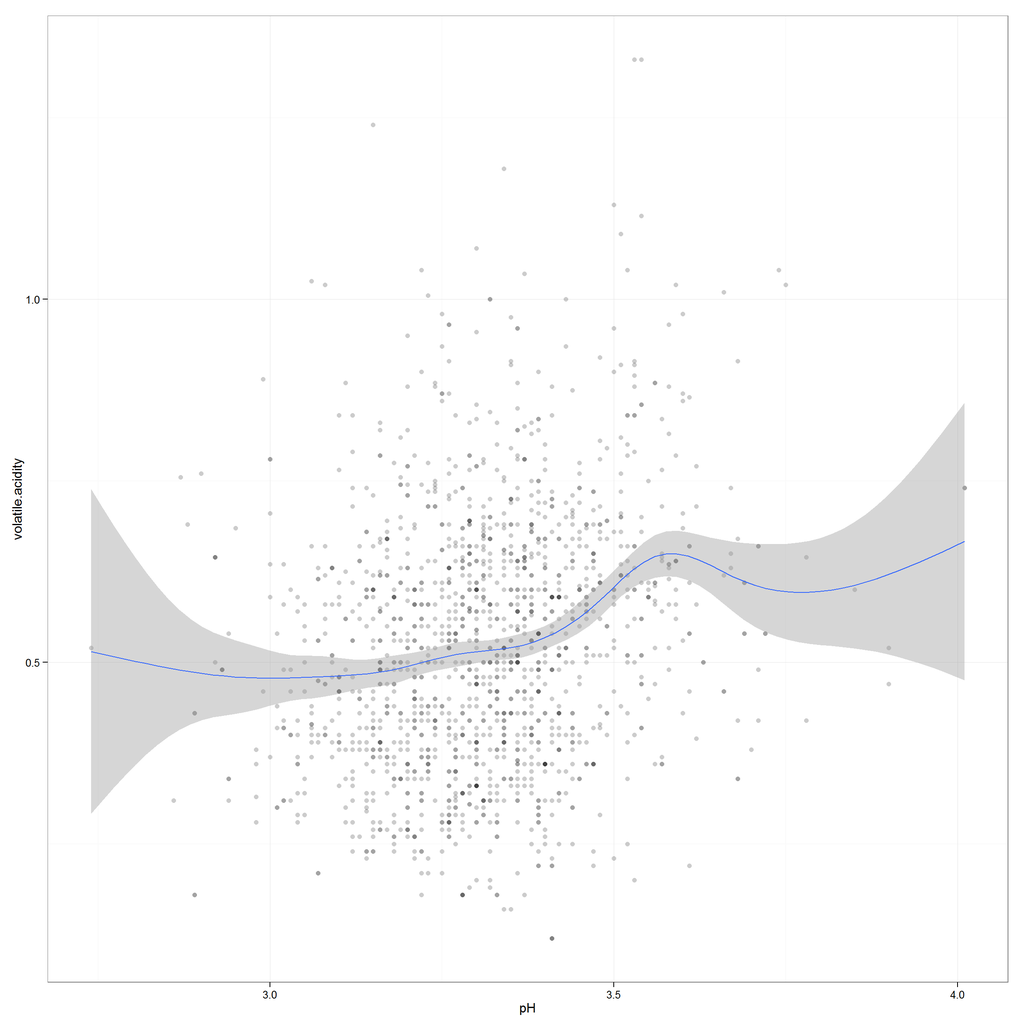

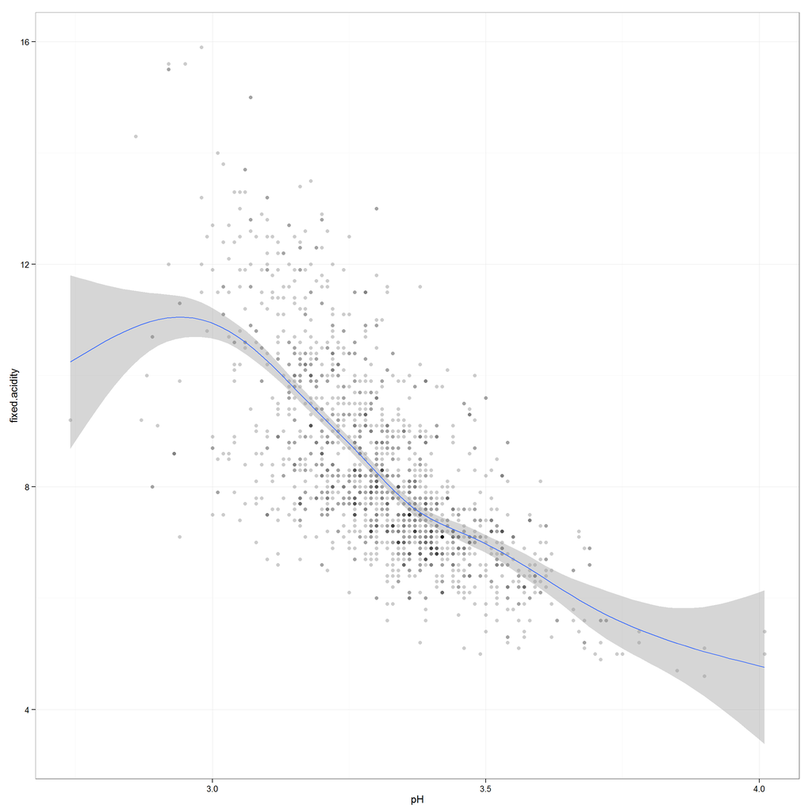

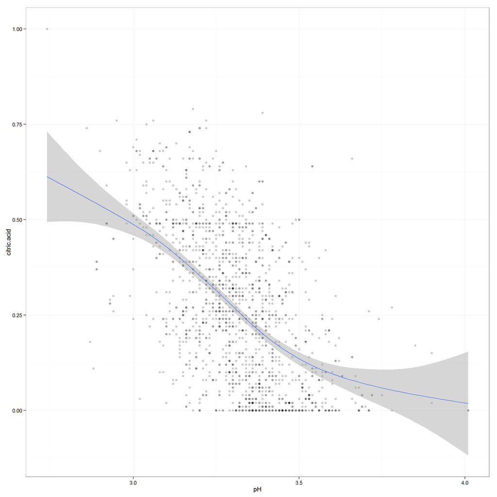

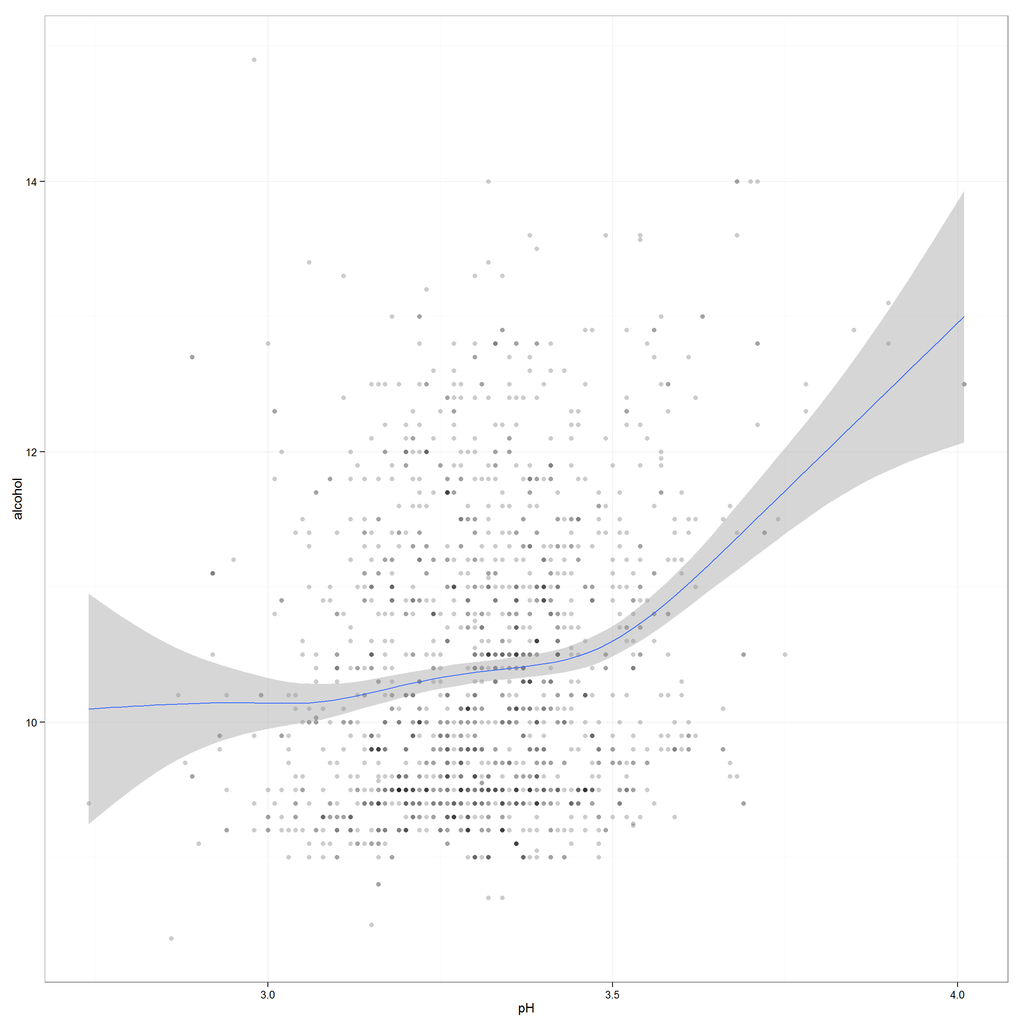

# Bivariate Analysis

### Talk about some of the relationships you observed in this part of the investigation. How did the feature(s) of interest vary with other features in the dataset?

As mentioned before, quality is our main feature. Based on the data, it showed strongest correlation with % of alcohol in the wine. Quality showed moderate to strong positive relation with

1. Alcohol
2. Citric Acid
3. Sulphates

And Quality showed moderate to strong negative relation with 1. Volatile Acidity 2. Total SO2

*Other Interesting Observations*

1. Distribution of alcohol across levels of quality is varying, esp. with level 5 has most outliers. And given the number of entries for 5, thats kind of expected. However for Category 7, it had 200 observations WITH NO OUTLIERS. Mean and Median were around same, and distribution looked normal. Also the mean of alcohol % in level 7 was atleast higher than 3rd quartile of any other level. That tells us that there is definite +ve relation between alcohol and higher quality levels.
2. Distribution of Volatile Acidity looked like mirror image of alcohol. It seems to have -ve relation with quality. Mean of lowest category was higher than 3rd quartile of any other level. And conversly, the mean of highest quality was less than first quartile of any other category.
3. There were way fewer outliers in citric.acid, relation is +ve with respect to quality for the given sample.
4. There is a +ve relation between sulphates and quality with huge number of outliers in category 5. Based on this data sulphates does impact quality in a good way.
5. TotalSO2 has somewhat varied distribution throughout quality. And gives a sense of somewhat normal distribution, which suggests that if TotalSO2 is low(around the mean of TotalSO2 at quality 4 and 8) we can predict the quality of Wine with higher probability.

### Did you observe any interesting relationships between the other features (not the main feature(s) of interest)?

Yes, they are described as follows:

1. Since pH is a measure of acidity, its natural to see a relationship between pH and other acidic variables. pH is inversaly related to fixed.acidity, citric acid. However to volatile acidity its not showing any meaningful relation.
2. pH is +vly related to alcohol, which is counter intuitive to my understanding that alcohol is a type of acid hence should have an inverse relation with pH, but for the given sample, this is not the case.

### What was the strongest relationship you found?

Strongest relation I found was between pH and fixed.Acidity. I also found strong relation between Density and fixed acidity which I wasn’t expecting. Again relationship between density and fixed acidity is counterintuitive. As density represents water density and should have theoretically the inverse relation with amount of acid in the wine.

# Multivariate Plots Section

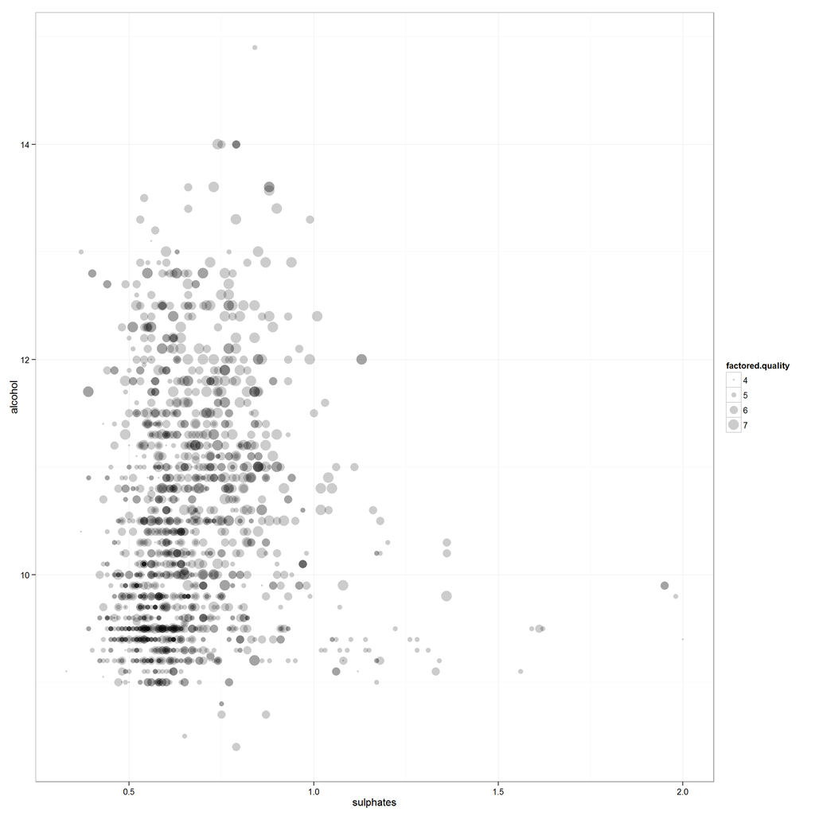

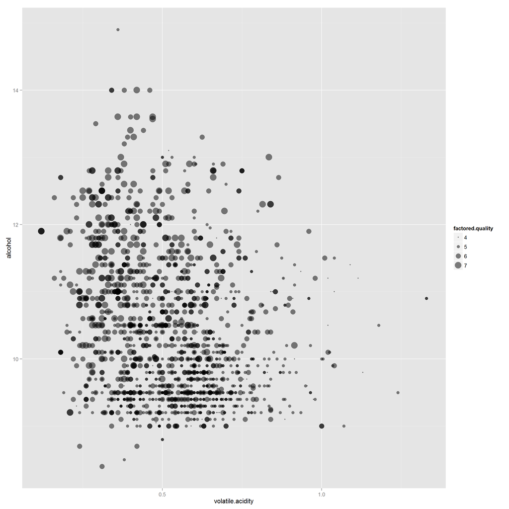

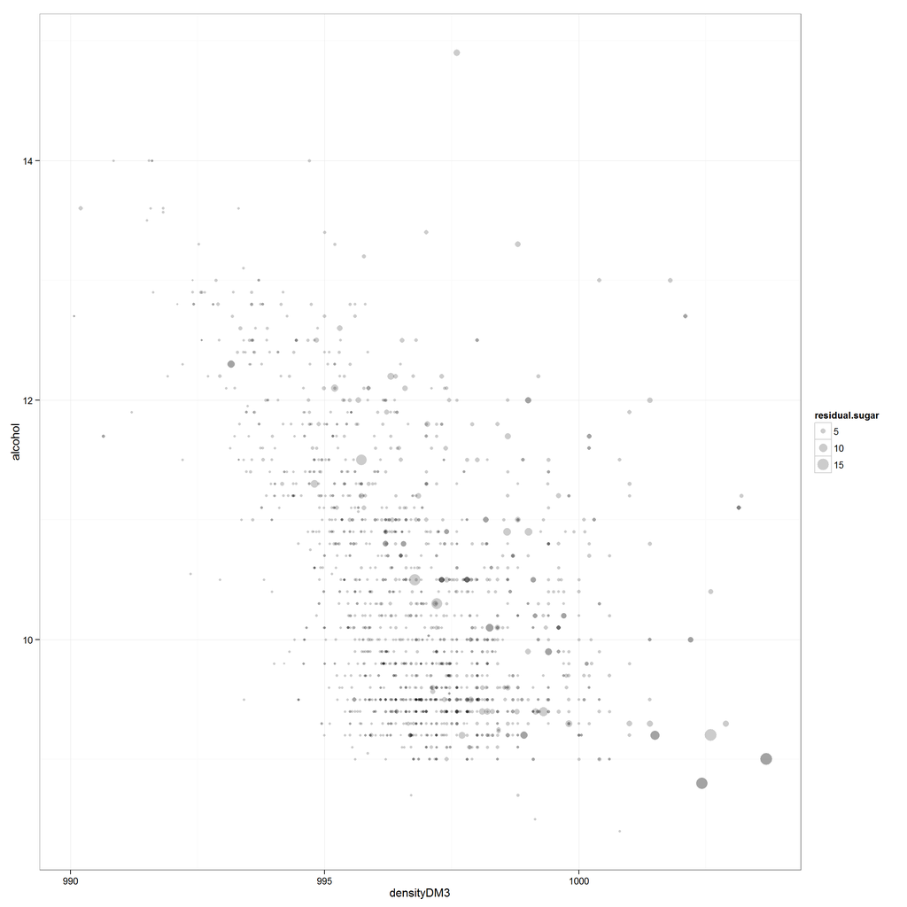

# Multivariate Analysis

### Talk about some of the relationships you observed in this part of the investigation. Were there features that strengthened each other in terms of looking at your feature(s) of interest?

I explored the relation with alcohol and sulphates over quality. Its evident from the scatter plot that alcohol is a stronger of the two when it comes to affect quality. That was evident from cor matrix but its always good to see that visually.

Volatile acidity and alcohol over quality seems fairly spread out. This suggests that both of them have roughly even say in the quality of wine. Interesting thing to note is that there isn’t even a single data point where volatile acidity is high > 1.0 and alcohol is low < 10% that is a high quality wine, which suggests that both alcohol and volatile acidity are pretty strong features and we seem to have a pretty reliable wine quality prediction once we combine the two. Atleast, we can easily predict the quality of wine if alcohol is low and volatile acidity is high and similarly when alcohol is high and volatile acidity is low.

### Were there any interesting or surprising interactions between features?

Yes, to see water density having an inverse relation with alcohol was interesting. However for the given sample, the contribution of residual sugar is not to be trusted, given it has so many outliers. Variable description says that density depends on alcohol and residual sugar. I am able to see an inverse relation with alcohol, however for residual sugar, it shows somewhat +ve relation with density, which is interesting.

I also found an interesting relation with fixed acidity and density and have plotted it in the final plot section.

### OPTIONAL: Did you create any models with your dataset? Discuss the strengths and limitations of your model.

I created the model with variables Alcohol, Volatile.acidity, sulphates and citric.acid as they seem to show relatioship with qualtiy as per EDA.

To train the the model, we need to separeate the data between test and training data set and see how good our model is.

I used stackOverflow help to figure out how to separate the data into training and test set. http://stackoverflow.com/questions/17200114/how-to-split-data-into-training-testing-sets-using-sample-function-in-r-program.

Now lets build our linear model using the training data. Based on our EDA we have some insights into what variables to pick and what not to pick.

```r
model1 <- lm(quality~alcohol+volatile.acidity+sulphates+citric.acid,data=train)
summary(model1)
```

```
##
## Call:
## lm(formula = quality ~ alcohol + volatile.acidity + sulphates +
##     citric.acid, data = train)
##
## Residuals:
##      Min       1Q   Median       3Q      Max
## -2.32902 -0.37364 -0.07855  0.45188  1.84830
##
## Coefficients:
##                  Estimate Std. Error t value Pr(>|t|)
## (Intercept)       2.75607    0.21949  12.557  < 2e-16 ***
## alcohol           0.28403    0.01712  16.589  < 2e-16 ***
## volatile.acidity -1.06554    0.12342  -8.633  < 2e-16 ***
## sulphates         0.73517    0.11060   6.647 4.57e-11 ***
## citric.acid      -0.03637    0.11061  -0.329    0.742
## ---
## Signif. codes:  0 '***' 0.001 '**' 0.01 '*' 0.05 '.' 0.1 ' ' 1
##
## Residual standard error: 0.6094 on 1173 degrees of freedom
## Multiple R-squared:  0.3304, Adjusted R-squared:  0.3282
## F-statistic: 144.7 on 4 and 1173 DF,  p-value: < 2.2e-16
```

#### *Analysis on Linear model*

Now lets try to predict the quality using the test data and see how good our model is doing. Given that our quality is in round figures so lets round the above predicted values too. And finally table the outcome i.e. predicted correctly vs predicted incorrectly.

```
##
##   0   1
## 170 223
```

# Final Plots and Summary

### Plot One

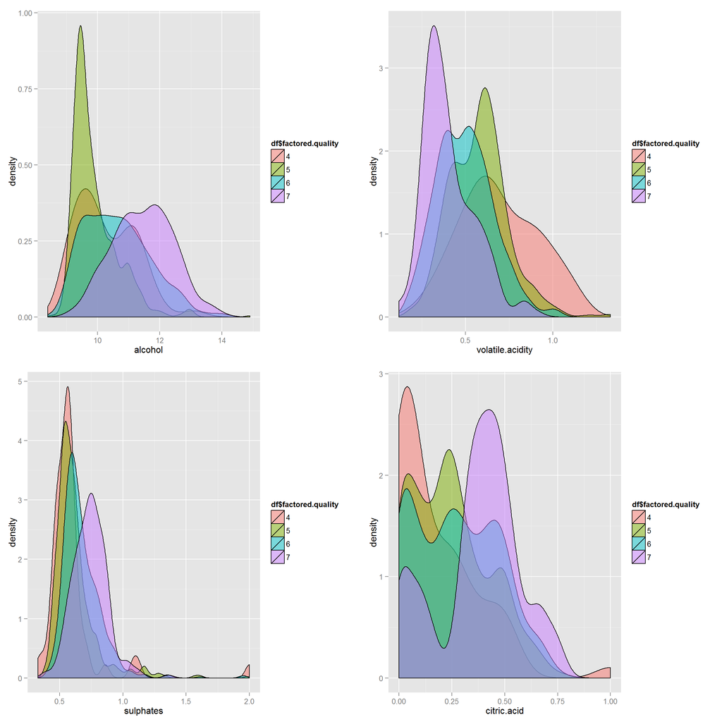

### Plot Two

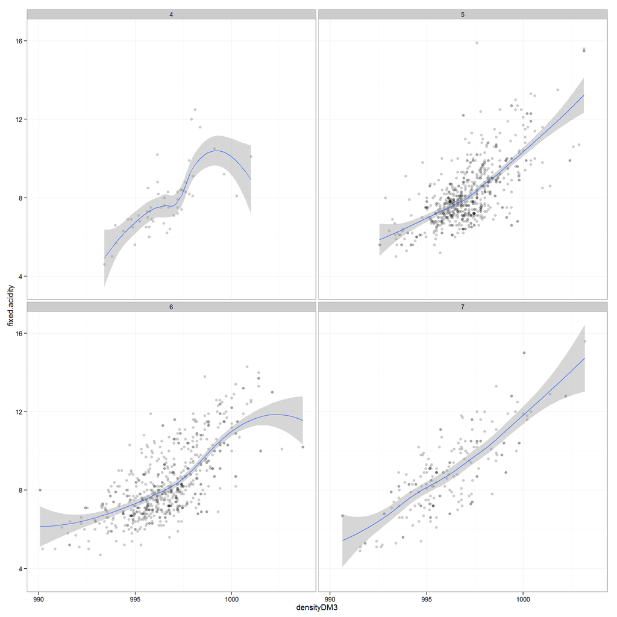

### Description Two

The second plot I want to highlight is something i discovered and wasn’t really expecting from the data set. +ve relation between fixed acidity and density. As I said earlier, the relation seems counterintuitive as Water density could be inversly related to fixed acidity (higher the water level, less is acidity). Not the case in this dataset. This relationship is true through different category levels.

### Plot Three

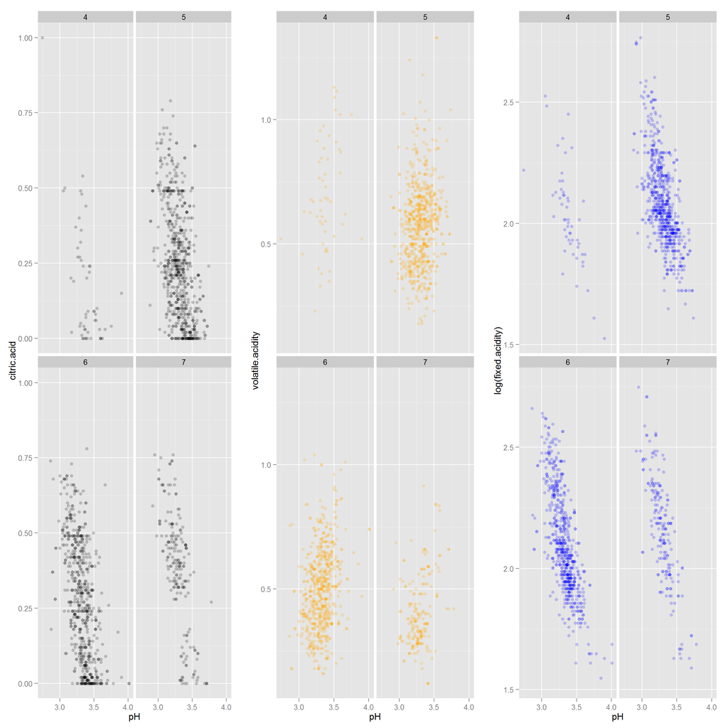

### Description Three

Final plot is the plot of pH vs different acidity. Interesting thing to note is that fixed acidity and citric acid are inversly related to pH(as expected). But not the volatile acidity. Volatile means something that would go away. It is quite possible that when pH score was measured, the volatile acidity present in wine was not encountered for as it could have been vanished already. True detector should be to take pH measurments when volatile acidity is present in wine and then report the data. Although that is just my theory!

# Reflection

After looking at the data, i had no idea where to start. First step was to look at existing variables, after looking at it, one thing became obvious is that we can understand the quality of wine from given variables. Readme from dataset helped too.

While creating this report, obviously the lecture materials helped, but also did the ggplot documentation. In particular I encountered following challenges while doing this project.

1. It was hard to arrange multiple charts in one grid. I had to search through gridExtra documentation to plot the summary function alongside two graphs in Univariate plots.
2. Initially I started with ggally graphs but I realized I was really interested just in correlation between features. Upon searching for better ways to plot cor matrix, i stumbled on corplot package, which does a better job than ggally for my purposes.
3. I found the number of outliers for given dataset in residual sugar and chlorides a whole lot and hence refrained myself from exploring them in detail. More data for level 3 and 8 would have been really nice. However given that quality is a perception of 3 experts(that too median) Its quite likely that we won’t get many data points for extreme levels. Its obviously challenging from analytics point of view. I think better metric to analyze would have been price than quality. As price is really qualitative and we could have ton of data for different price categories (10-20 USD), (20-50 USD) and so on.

Further work:

1. Identify variables which showed relationship to quality have statistical relationship and not just from this sample. i.e. calculate Confidence interval for volatile acidity etc. to predict quality.
2. Improve the model, may be logistic regression , maybe something else.